# 01_sqrt_lake_area

## 01_sqrt_lake_area

#### Question

1. Personally, I find it difficult to interpret large areas. I prefer to find an approximate length to help imagine the scale. If you approximate the shape as a square, the calculation is pretty quick.

   For example, maybe you are told that the lake below has an area of $290$ $\mathrm{miles^2}$.

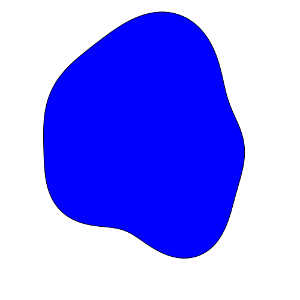

   If you approximate the shape as a square, what is the edge length (in miles)? In other words, what is the approximate distance, in miles, across the lake?

#### Question

2. Personally, I find it difficult to interpret large areas. I prefer to find an approximate length to help imagine the scale. If you approximate the shape as a square, the calculation is pretty quick.

   For example, maybe you are told that the lake below has an area of $140$ $\mathrm{miles^2}$.

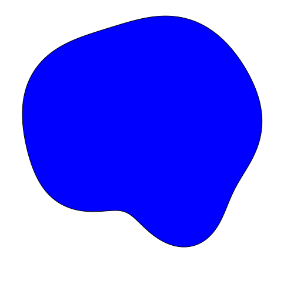

   If you approximate the shape as a square, what is the edge length (in miles)? In other words, what is the approximate distance, in miles, across the lake?

#### Question

3. Personally, I find it difficult to interpret large areas. I prefer to find an approximate length to help imagine the scale. If you approximate the shape as a square, the calculation is pretty quick.

   For example, maybe you are told that the lake below has an area of $5900$ $\mathrm{miles^2}$.

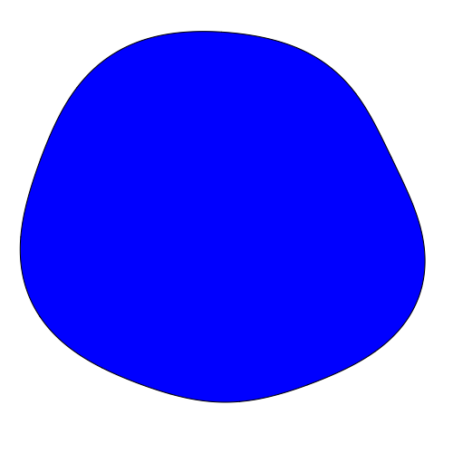

   If you approximate the shape as a square, what is the edge length (in miles)? In other words, what is the approximate distance, in miles, across the lake?

#### Question

4. Personally, I find it difficult to interpret large areas. I prefer to find an approximate length to help imagine the scale. If you approximate the shape as a square, the calculation is pretty quick.

   For example, maybe you are told that the lake below has an area of $150$ $\mathrm{miles^2}$.

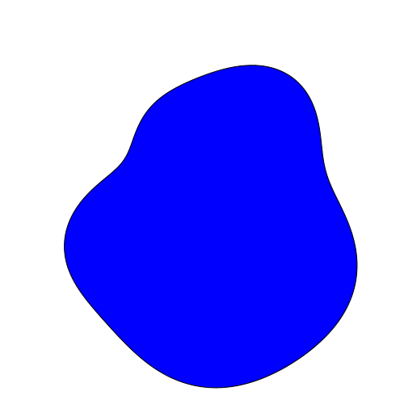

   If you approximate the shape as a square, what is the edge length (in miles)? In other words, what is the approximate distance, in miles, across the lake?

#### Question

5. Personally, I find it difficult to interpret large areas. I prefer to find an approximate length to help imagine the scale. If you approximate the shape as a square, the calculation is pretty quick.

   For example, maybe you are told that the lake below has an area of $2300$ $\mathrm{miles^2}$.

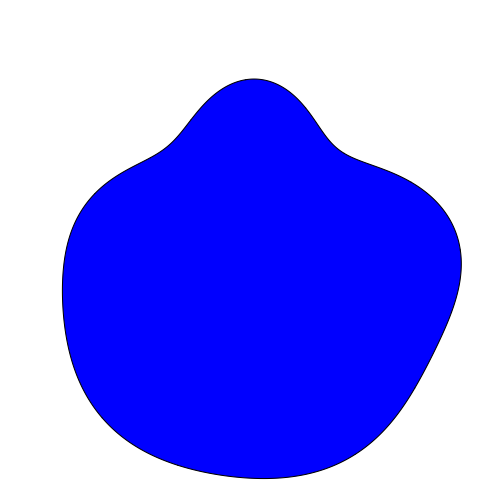

   If you approximate the shape as a square, what is the edge length (in miles)? In other words, what is the approximate distance, in miles, across the lake?

#### Question

6. Personally, I find it difficult to interpret large areas. I prefer to find an approximate length to help imagine the scale. If you approximate the shape as a square, the calculation is pretty quick.

   For example, maybe you are told that the lake below has an area of $78$ $\mathrm{miles^2}$.

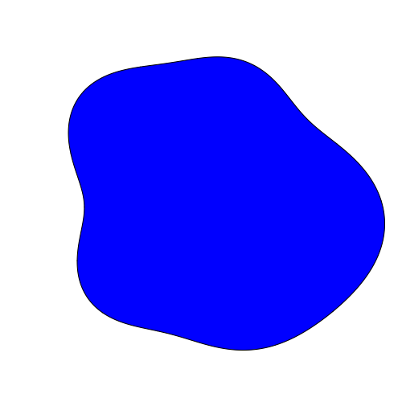

   If you approximate the shape as a square, what is the edge length (in miles)? In other words, what is the approximate distance, in miles, across the lake?

#### Question

7. Personally, I find it difficult to interpret large areas. I prefer to find an approximate length to help imagine the scale. If you approximate the shape as a square, the calculation is pretty quick.

   For example, maybe you are told that the lake below has an area of $1500$ $\mathrm{miles^2}$.

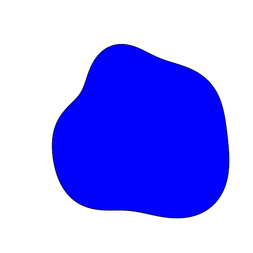

   If you approximate the shape as a square, what is the edge length (in miles)? In other words, what is the approximate distance, in miles, across the lake?

#### Question

8. Personally, I find it difficult to interpret large areas. I prefer to find an approximate length to help imagine the scale. If you approximate the shape as a square, the calculation is pretty quick.

   For example, maybe you are told that the lake below has an area of $760$ $\mathrm{miles^2}$.

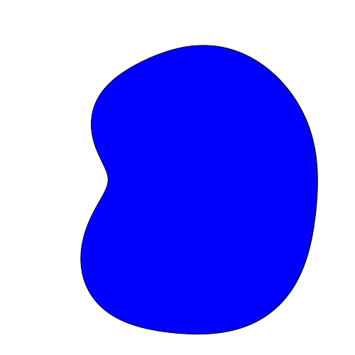

   If you approximate the shape as a square, what is the edge length (in miles)? In other words, what is the approximate distance, in miles, across the lake?